# Info1A-MPSI-PCSI_TP09_Corrigé_v0

## TP09 : algorithmes dichotomiques

- Éléments de cours sur : <à venir>
- Éléments de cours sur : <à venir>

Raccourcis pour Jupyter :

- Maj + Enter : exécute la cellule courante ;
- Esc b : crée une cellule de code au-dessous de la cellule courante ('b' pour 'below') ;
- Alt + Enter : exécute la cellule courante et créé une cellule de code à sa suite ;
- Esc + m : transforme une cellule de code (mode 'Code') en cellule de texte (mode 'Markdown') ;
- Esc + y : transforme cellule de texte (mode 'Markdown') en une cellule de code (mode 'Code').

## Introduction

Les algorithmes dichotomiques présentés ici permettent d'obtenir une amélioration de la complexité (linéaire) des algorithmes de recherche dans une liste (*moyennant que la liste dans laquelle on recherche une valeur soit triée*) et de calcul d'une puissance $n^{ème}$.

**À faire pendant le temps du TP :**

- première heure : Exercice 1 ;
- deuxième heure : Exercice 2

## Exercice 1 recherche dichotomique dans une liste triée

**Q1** *Préliminaire*

Afin d'introduire l'idée présidant à l'algorithme de recherche dichotomique dans une liste triée, on présente le jeu de Hi-Lo (que l'on pourra nommer "C'est plus ! C'est moins") dans lequel on cherche, par essais successifs, à déterminer un nombre entier, choisi ici aléatoirement par la machine.

On exécutera la cellule suivante afin de rendre disponible la fonction `jouer(N)`.

```python
from TP09_annexe import jouer
```

[output not shown]

En exécutant l'appel `jouer(N)`, pour une valeur fixée de $N$, il vous sera demander de faire au maximum vingt essais pour deviner un entier $n$, compris entre $1$ et $N$, choisi aléatoirement par la machine.  
Chaque essai consistera à proposer un nombre compris entre $1$ et $N$, et la machine indiquera si le nombre à trouver a été trouvé ou s'il est plus grand ou plus petit que le nombre proposé.

**Q1.a**

Tester le jeu en prenant $N=100$.  
*Pour tester le jeu, on devra décommenter l'instruction `jouer(100)` dans la cellule ci-dessus.*

```python
#jouer(100) ## faire "Kernel interrupt si la cellule reste bloquée sur [*]"
```

Arrive-t-on facilement à trouver le nombre choisi par la machine ? Une stratégie se fait-elle jour pour trouver le plus rapidement possible le nombre choisi par la machine ?

*Q1.a corrigé*

- si la valeur $m$ est égale à la valeur à trouver, la recherche se termine ;
- si la valeur $m$ est plus petite que la valeur à trouver, on poursuivra la recherche dans l'intervalle $[\![a_{n+1};b_{n+1} ]\!] = [\![a_n;m - 1]\!]$ ;
- si la valeur $m$ est plus grande que la valeur à trouver, on poursuivra la recherche dans l'intervalle $[\![a_{n+1};b_{n+1} ]\!] = [\![m+1;b_n ]\!]$.

**Q2.b**

Mettre en œuvre la stratégie qui s'est faite jour à la question **1.a** en complétant dans la cellule suivante le code visant à trouver un nombre $x$ choisi aléatoirement entre $a=1$ et $b=N$ (inclus), en testant des valeurs, $y$, bien choisies.  
À chaque itération, on restreindra l'intervalle de recherche de la valeur $x$, $[\![a;b]\!]$, en actualisant les valeurs des variables `a` et `b`.  
On actualisera la variable `compteur` de sorte à pouvoir afficher en fin d'algorithme le nombre d'essais nécessaires.  
Afin de garder trace des valeurs testées, on les enregistrera dans une liste `L` (le nombre d'éléments de `L` sera bien sûr égal à la valeur de la variable `compteur`).

```python
from random import randint

N = 1000
x = randint(1, N)

y = 0 # choix d'une valeur arbitraire différente de a afin d'initier une première itération de la boucle while
a, b = 1, N
L, compteur = [], 0
while y != x:
    y = (...)
    if y < x:
        ... # réduction de l'intervalle de recherche

    ...
    ... :
        ... # réduction de l'intervalle de recherche

print(compteur, L)
```

```
  File "C:\Users\baill\AppData\Local\Temp/ipykernel_13404/3308624974.py", line 15
    ... :
         ^
SyntaxError: invalid syntax
```

```python
from random import randint

N = 1000
x = randint(1, N)

y = 0 # choix d'une valeur arbitraire différente de a afin d'initier une première itération de la boucle while
a, b = 1, N
L, compteur = [], 0
while y != x:
    y = (...)
    if y < x:
        ... # réduction de l'intervalle de recherche

    ...
    ... :
        ... # réduction de l'intervalle de recherche

print(compteur, L)
```

```
  File "C:\Users\baill\AppData\Local\Temp/ipykernel_13404/3308624974.py", line 15
    ... :
         ^
SyntaxError: invalid syntax
```

*Q2.b corrigé*

```python
from random import randint

N = 1000
x = randint(1, N)

y = 0 # choix d'une valeur arbitraire différente de a afin d'initier une première itération de la boucle while
a, b = 1, N # extrémités de l'intervalle de recherche avant toute proposition
L, compteur = [], 0 # initialisation de la liste des valeurs proposées, L, et du compteur de proposition, compteur.
while y != x:       # tant que la valeur à trouver, x, n'a pas été trouvée (i.e. tant que y n'a pas pris la valeur x)
    y = (a + b) // 2# on propose une valeur entière située "au milieu" de l'intervalle de recherche
                    # afin de proposer une valeur entière, on choisi de proposer le quotient dans la division euclidienne
                    # de a + b par 2, ce qui revient à proposer l'entier le plus grand inférieur ou égal à (a+b) / 2
    ## actualisation de la liste des valeurs proposées :
    L.append(y)
    ## actualisation du compteur (nombre de valeurs proposées)
    compteur = compteur + 1
    if y < x:   # si la valeur proposée, y, est inférieure strictement à la valeur à trouver, x
        # réduction de l'intervalle de recherche aux entiers de l'intervalle [y + 1, b] :
        a = y + 1   # <--- l'extrémité gauche, a, est à modifier
        b = b       # <--- bien sûr cette ligne peut être omise (la valeur de b n'est pas à modifier)
    elif x < y: # si la valeur proposée, y, est supérieure strictement à la valeur à trouver, x
        # réduction de l'intervalle de recherche aux entiers de l'intervalle [a, y - 1] :
        a = a       # <--- bien sûr cette ligne peut être omise (la valeur de a n'est pas à modifier)
        b = y - 1   # <--- l'extrémité droite, b, est à modifier
    ## Note : on omet ici le else (qui consisterait à traiter le cas restant, où y = x, car la condition du while
    ## traitera ce cas en terminant la boucle si la valeur à trouver à été proposée)

print(compteur, L)
```

```
9 [500, 250, 375, 437, 468, 484, 492, 488, 490]
```

Si l'on retire les commentaires du programme, et la variable `compteur` (dont la valeur coïncide avec la valeur de `len(L)`), et les actualisations inutiles des variables `a` et `b`, le programme est le suivant :

```python
from random import randint

N = 1000
x = randint(1, N)

y = 0
a, b = 1, N
L = []
while y != x:
    y = (a + b) // 2
    L.append(y)
    if y < x:
        a = y + 1
    elif x < y:
        b = y - 1

print("valeur à trouver :", x)
print("Liste des valeurs proposées :", L)
print("dernière valeur proposée :", L[-1], "; Nombre de propositions :", len(L))
```

```
valeur à trouver : 509
Liste des valeurs proposées : [500, 750, 625, 562, 531, 515, 507, 511, 509]
dernière valeur proposée : 509 ; Nombre de propositions : 9
```

**Q1.c** Proposer une majoration du nombre d'essais nécessaires en fonction de $N$ (on pourra commencer par considérer des valeurs de $N$ qui sont des puissances de $2$, notées $2^m$)

Vérifier la cohérence avec les résultats obtenus en **Q1.b**, en effectuant plusieurs tests du programme précédent, pour plusieurs valeurs de $N$.

*Q1.c corrigé*

On demande ici une *proposition* de majoration dans le sens où aucune démonstration n'est attendue.  
Dans le corrigé de cette question, la démonstration par récurrence de la majoration **( * )** n'est pas présentée (on trouvera une démonstration analogue, faite, dans les éléments de cours sur la recherche dichotomique dans une liste triée).  
Il est également admis **(** )** que la valeur à trouver est nécessairement dans l'intervalle de recherche délimité par les valeurs des variables `a` et `b`.

- Majoration du nombre d'essais pour des valeurs de $N$ de la forme $2^m$ (donc lorsque $N$ est égal à une puissance de $2$) :

Si $N$ est de la forme $2^m$, le nombre de valeurs initialement dans l'intervalle $[\![1;N]\!]$ est égal à $2^m$, et après une proposition, l'intervalle contient (au plus) $\frac{2^m}{2}=2^{m-1}$ valeurs.
On démontre **(*)** alors, par récurrence, qu'après $p$ propositions, le nombre de valeurs dans l'intervalle de recherche est, au plus, égal à $\frac{2^m}{2^p}=2^{m-p}$.
Ainsi, la recherche aura nécessairement terminé dès que l'on aura fait un nombre de propositions au plus égal à $p_N$, où $p_N$ est le plus petit entier naturel $p$ tel que $2^{m-p}\leqslant 1$. En effet, après $p_N$ propositions, l'intervalle de recherche contiendra nécessairement au plus une valeur, valeur qui sera proposée et sera nécessairement égale à la valeur à trouver, puisqu'il est assuré **(** )** que la valeur à trouver est dans l'intervalle de recherche.
La résolution de l'inéquation d'inconnue $p$, $2^{m-p}\leqslant1$, se ramène aux équivalences suivantes :
$$ \left(2^{m-p}\leqslant 1\right) \Longleftrightarrow \left(2^{m}\leqslant 2^{p}\right) \Longleftrightarrow \left(m\leqslant p\right). $$ On en conclut que la recherche aura terminé après au plus $p_N=m$ propositions.

- Majoration du nombre d'essais pour une valeur quelconque de $N$ :

En continuant d'admettre qu'avant toute itération et à la fin de chaque itération de la boucle `while`, la valeur cherchée, `x` est dans l'intervalle de recherche d'extrémités `a` et `b`, en admettant encore que le nombre d'entiers dans l'intervalle de recherche diminue de moitié à chaque itération tant qu'il n'est pas réduit à un seul élément au plus, alors, si on note $m_N$ le plus petit entier tel que $n\leqslant 2^{m_N}$, alors le raisonnement précédent donne que la recherche aura terminé après au plus $p_N=m_N$ itérations.

Sachant que $N>0$, la résolution de l'inéquation d'inconnue $m$, $N\leqslant 2^{m}$, se ramène aux équivalences suivantes :
$$ \left( N\leqslant 2^{m} \right) \Longleftrightarrow \left( \ln N \leqslant \ln 2^m \right) \Longleftrightarrow \left( \ln N \leqslant m \ln 2 \right) \Longleftrightarrow \left( \frac{\ln N}{\ln 2} \leqslant m \right) \Longleftrightarrow \left( \log_2 N \leqslant m \right) \Longleftrightarrow \left( m \geqslant \lceil \log_2 N \rceil \right). $$ où $\lceil \log_2 N \rceil$ désigne la partie entière supérieure de $\log_2 N$ (logarithme en base $2$ de $N$, dont une valeur approchée est obtenue par appel aux fonctions `log2` - logarithme en base 2, et `ceil` - partie entière supérieure, du module `math`).

On en conclut que la recherche aura terminé après au plus $p_N = \lceil \log_2 N \rceil$ propositions.

- tests

Afin de confronter ces résultats à l'expérimentation, on propose la fonction suivante, `teste_algo`, implémentant la recherche d'une suite optimale de propositions pour une valeur à trouver choisie au hasard entre dans un intervalle $[\![1;N]\!]$, en suivant l'algorithme proposé.  
La fonction `teste_algo` prend en paramètre un entier $N \geqslant 1$, affiche les extrémités successives des intervalles de recherche et leurs nombres d'éléments entiers, et renvoie la liste des propositions faites, ainsi que leur nombre et la valeur de la borne supérieure estimée pour le nombre de propositions à faire.

```python
def teste_algo(N):
    from random import randint
    from math import log2, ceil

    x = randint(1, N)
    m = ceil(log2(N))
    print('Valeur à trouver :', x)
    print('Nombre maximal d\'essais estimé :', m)
    y = 0
    a, b = 1, N
    L = []
    while y != x:
        print(f'intervalle de recherche :  [{a}, {b}] (nombre d\'éléments : {b - a + 1})')
        y = (a + b) // 2
        L.append(y)
        if y < x:
            a = y + 1
        elif x < y:
            b = y - 1
    print("Dernière valeur proposée :", y)
    print("Valeur trouvée avec", len(L), "propositions.")
    return L, len(L), m
```

```python
teste_algo(100)
```

```
Valeur à trouver : 93
Nombre maximal d'essais estimé : 7
intervalle de recherche :  [1, 100] (nombre d'éléments : 100)
intervalle de recherche :  [51, 100] (nombre d'éléments : 50)
intervalle de recherche :  [76, 100] (nombre d'éléments : 25)
intervalle de recherche :  [89, 100] (nombre d'éléments : 12)
intervalle de recherche :  [89, 93] (nombre d'éléments : 5)
intervalle de recherche :  [92, 93] (nombre d'éléments : 2)
intervalle de recherche :  [93, 93] (nombre d'éléments : 1)
Dernière valeur proposée : 93
Valeur trouvée avec 7 propositions.
```

```
([50, 75, 88, 94, 91, 92, 93], 7, 7)
```

```python
teste_algo(1000)
```

```
Valeur à trouver : 27
Nombre maximal d'essais estimé : 10
intervalle de recherche :  [1, 1000] (nombre d'éléments : 1000)
intervalle de recherche :  [1, 499] (nombre d'éléments : 499)
intervalle de recherche :  [1, 249] (nombre d'éléments : 249)
intervalle de recherche :  [1, 124] (nombre d'éléments : 124)
intervalle de recherche :  [1, 61] (nombre d'éléments : 61)
intervalle de recherche :  [1, 30] (nombre d'éléments : 30)
intervalle de recherche :  [16, 30] (nombre d'éléments : 15)
intervalle de recherche :  [24, 30] (nombre d'éléments : 7)
Dernière valeur proposée : 27
Valeur trouvée avec 8 propositions.
```

```
([500, 250, 125, 62, 31, 15, 23, 27], 8, 10)
```

- Nombre de propositions pour toutes les valeurs de $x$ entre $1$ et $N$ pour $N=100$ :

*À titre d'illustration (non demandé en TP)*, pour, par exemple, $N=100$, on peut afficher le nombre de propositions faites en appliquant l'algorithme proposé, pour toutes les valeurs $x$ à trouver possibles, comprises entre $1$ et $N=100$, en se dotant de la fonction `trouve_algo(N, x)` implémentant la recherche dichotomique d'une valeur $x$ comprise entre $1$ et un entier $N\geqslant 1$ donné, et renvoyant le nombre de propositions faites :

```python
def trouve_algo(N, x):
    y = 0
    a, b = 1, N
    compteur = 0
    while y != x:
        y = (a + b) // 2
        compteur += 1
        if y < x:
            a = y + 1
        elif x < y:
            b = y - 1
    return compteur
```

On construit alors, pour $N\geqslant 1$ donné, ici $N=100$, la liste du nombre de propositions faites pour trouver chaque valeur $x$ comprise entre $1$ et $N$ :

```python
N = 100
Lresultats = []
for x in range(1, N + 1):
    Lresultats.append(trouve_algo(N, x))
```

On peut alors obtenir le tracé des nombre de propositions en fonction de la valeur de $x$ :

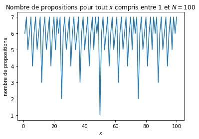

```python
import matplotlib.pyplot as plt

N = 100

fig, ax = plt.subplots()

ax.plot([x for x in range(1, N + 1)], [trouve_algo(N, x) for x in range(1, N + 1)])
ax.set_title("Nombre de propositions pour tout $x$ compris entre $1$ et $N=100$")
ax.set_xlabel('$x$')
ax.set_ylabel('nombre de propositions')
plt.show()
```

*En complément encore - et sans que cela soit attendu en TP*, on peut afficher sur un même graphique, le nombre moyen de propositions à faire pour trouver une valeur $x$ de l'intervalle $[\![1;N]\!]$, pour toutes les valeurs de $N$ comprises entre $1$ et $1000$, ainsi que la valeur du majorant, $\lceil \log_2 N \rceil$ du nombre de propositions à faire pour $N$ donné.

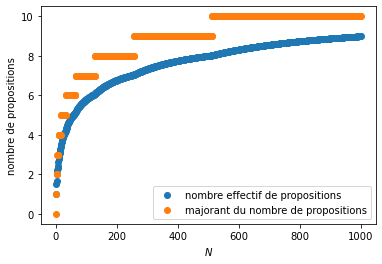

```python
import matplotlib.pyplot as plt

from math import log2, ceil

Nmax = 1000

fig, ax = plt.subplots()

ax.scatter([N for N in range(1, Nmax + 1)], [sum([trouve_algo(N, x)for x in range(1, N + 1)]) / N
                                           for N in range(1, Nmax + 1)],
            label = 'nombre effectif de propositions')
ax.scatter([N for N in range(1, Nmax + 1)], [ceil(log2(N)) for N in range(1, Nmax + 1)],
            label = 'majorant du nombre de propositions')
ax.set_xlabel('$N$')
ax.set_ylabel('nombre de propositions')
ax.legend()
plt.show()
```

**Q1.d**

Définir une liste $L1024$ de $1024$ entiers tirés au hasard entre $1$ et $10000$.

```python
from random import randint
L1024 = [...]
```

Ordonner cette liste à l'aide de la méthode `.sort` en exécutant la cellule suivante :

```python
L1024.sort()
```

Définir une fonction `rechval(L, x)` (déjà implémentée précédemment dans l'année), utilisant un parcours de la liste `L` et renvoyant un booléen, `True` ou `False`, selon que la liste `L` contient ou non la valeur `x`

```python
def rechval(L, x):
    ...
```

Tester cette fonction pour savoir si la liste `L1024` contient ou non la valeur $6543$.  
Combien de comparaisons au pire seront effectuées lors de l'appel à la fonction ?

```python
rechval(L1024, 6543)
```

Par une méthode analogue à celle de la question **Q2.b** :

- imaginer une méthode de recherche permettant déterminer si une valeur `x` appartient à une liste `L`, **supposée triée**, nécessitant en moyenne moins de comparaison pour obtenir le résultat

$\quad\square$ Par la méthode imaginée, combien de comparaisons doit-on effectuer au plus pour déterminer si une valeur appartient ou non à la liste triée `L1024` ?

$\quad\square$ Par cette même méthode, combien de comparaisons au plus seraient nécessaires pour déterminer si une valeur `x` appartient ou non à une liste triée `L` comportant $n$ éléments ? Argumenter.

$\quad\square$ Est-il possible d'obtenir aussi la position de la valeur `x` dans la liste triée `L` ?

- Application :

En combien d'étapes peut-on déterminer si un élève de PCSI ou de MPSI a rendu sa copie si on dispose du paquet des copies rendues, triée dans l'ordre alphabétique ?

*Q1.d corrigé*

Définir une liste $L1024$ de $1024$ entiers tirés au hasard entre $1$ et $10000$.

```python
from random import randint
L1024 = [randint(1, 10000) for i in range(1024)]
```

Ordonner cette liste à l'aide de la méthode `.sort` en exécutant la cellule suivante :

```python
L1024.sort()
```

Définir une fonction `rechval(L, x)` (déjà implémentée précédemment dans l'année), utilisant un parcours de la liste `L` et renvoyant un booléen, `True` ou `False`, selon que la liste `L` contient ou non la valeur `x`

```python
def rechval(L, x):
    for i in range(len(L)):
        if L[i] == x:
            return True
    return False
```

Tester cette fonction pour savoir si la liste `L1024` contient ou non la valeur $6543$.  
Combien de comparaisons au pire seront effectuées lors de l'appel à la fonction ?

```python
rechval(L1024, 6543)
```

```
False
```

Par appel à la fonction `rechval` se sont au plus $n={\rm len}(L)$ comparaisons - au travers du test `L[i] == x`, qui seront effectuées pour déterminer si la valeur $x$ est ou non dans la liste $L$.  
Ce nombre maximal de $n$ comparaisons étant atteint dans les cas où $x$ est en dernière position dans $L$ ou lorsque $x$ n'est pas dans $L$ (pires cas).

Par une méthode analogue à celle de la question **Q2.b** :

- imaginer une méthode de recherche permettant déterminer si une valeur `x` appartient à une liste `L`, **supposée triée**, nécessitant en moyenne moins de comparaison pour obtenir le résultat

La liste étant supposée triée, on peut imaginer d'examiner en premier lieu une valeur au milieu de la liste et de poursuivre la recherche à gauche de cette valeur si cette valeur est supérieure à la valeur cherchée, et à droite sinon.  
En gardant trace, à chaque étape, de la position de la grande valeur testée qui soit inférieure à la valeur cherchée, et de la position de la petite valeur testée qui soit supérieure à la valeur cherchée, on pourra, en testant à chaque fois la valeur située à la position médiane entre ces deux valeurs, réduire de moitié la portion de liste dans laquelle peut se trouver la valeur cherchée.  
Si la valeur cherchée est dans la liste, elle sera trouvée en tant que valeur *au milieu* de l'intervalle de recherche, au pire lorsque cet intervalle de recherche ne comportera plus qu'une seule valeur.

$\quad\square$ Par la méthode imaginée, combien de comparaisons doit-on effectuer au plus pour déterminer si une valeur appartient ou non à la liste triée `L1024` ?

La liste `L1024` contient $1024=2^{10}$ valeurs. Si on cherche dans cette liste une valeur $x$, on peut, par la méthode imaginée, espérer réduire, à chaque nouveau test, de moitié la longueur (nombre d'éléments) de la portion de liste dans laquelle on recherche la valeur.  
Ainsi, après 10 tests au plus la zone de recherche ne comportera pas plus d'une valeur.

$\quad\square$ Par cette même méthode, combien de comparaisons au plus seraient nécessaires pour déterminer si une valeur `x` appartient ou non à une liste triée `L` comportant $n$ éléments ? Argumenter.

Comme vu précédemment (**Q1.c**), considérant la partie entière supérieure du logarithme en base $2$ de $n$, $m=\lceil\log_2 n \rceil$, on peut majorer le nombre d'éléments présents dans la liste, $n$, par $2^m$, et majorer le nombre d'éléments restants dans la zone de recherche après $p$ tests, par $2^{m-p}$, de sorte qu'après $p=\lceil\log_2 n \rceil$ itérations, il soit assuré qu'il ne reste pas plus d'une valeur dans la zone de recherche.

$\quad\square$ Est-il possible d'obtenir aussi la position de la valeur `x` dans la liste triée `L` ?

Dans la mesure où la zone de recherche est connue par la position dans $L$ de ses extrémités, et que les valeurs à tester sont données par leur position dans $L$, à tout moment de l'application de l'algorithme de recherche, on connaît la position de la valeur testée, et donc la position de la valeur à trouver au moment où on la trouve.

- Application :

En combien d'étapes peut-on déterminer si un élève de PCSI ou de MPSI a rendu sa copie si on dispose du paquet des copies rendues, triée dans l'ordre alphabétique ?

Si le nombre de copies rendues est de $48$, il faudra examiner l'entête d'au plus $\lceil\log_2 48 \rceil$ copies avant de savoir si un élève donné a rendu sa copie :

```python
from math import log2, ceil
ceil(log2(48))
```

```
6
```

Si l'on recherche une copie parmi $100$ copies triées dans l'ordre alphabétique - soit environ deux fois plus de copies, il ne faut qu'un essai de plus :

```python
from math import log2, ceil
ceil(log2(100))
```

```
7
```

On voit là la trace de la propriété de calcul de la fonction logarithme, selon laquelle, pour le logarithme en base $2$ : $$ log_2 (2n) = 1+ log_2(n). $$

**Q2**

Un premier algorithme de recherche dichotomique d'une valeur $x$ dans une liste triée `L`, consiste à appliquer la méthode mise en œuvre à la question **Q1** à la recherche d'un indice $i$, compris entre $0$ et ${\rm len(L)}-1$ tel que ${\rm L}[i] = x$.

**Q2.a**

$\quad\square$ Décrire une adaptation possible de l'algorithme mis en œuvre en **Q1.b** pour rechercher une valeur $x$ dans une liste $L$ triée (dans l'ordre croissant).

On mettra l'algorithme en œuvre au travers d'une fonction `rech_dicho` prenant en argument une liste triée $L$ et une valeur $x$ et renvoyant `True` ou `False` selon que $x\in L$ ou non. On supposera que le type des valeurs dans $L$ est ordonné.  
Il s'agira d'initialiser un intervalle d'indices $[\![a, b]\!]$ avec les valeurs $a=0$ et $b={\rm len}(L)-1$, dont on réduira l'étendue au fil des itérations en actualisant les valeurs de deux variables entières `a` et `b`.  
Comme il n'est pas assuré qu'il existe un indice $i$, $0\leqslant i\leqslant {\rm len}(L)-1$, tel que ${\rm L}[i] =x$, il faudra réfléchir à une condition de terminaison de la boucle `while` adaptée.  
On complètera le squelette de fonction suivant.

```python
def rech_dicho(L, x):
    a, b = 0, len(L) - 1
    while False: ## <--- à modifier
        ...
        if ...:
            ...
        elif ...:
            ...
        else:
            ...
    return ...
```

$\quad\square$ Compléter ci-dessous le squelette :

```python
def rech_dicho(L, x):
    a, b = 0, len(L) - 1
    while False: ## <--- à modifier
        ...
        if ...:
            ...
        elif ...:
            ...
        else:
            ...
    return ...
```

- tests

```python
rech_dicho([1, 5, 8, 9, 9, 10], 1)
```

```
Ellipsis
```

```python
rech_dicho([1, 5, 8, 9, 9, 10], 9)
```

```
Ellipsis
```

```python
rech_dicho([1, 5, 8, 9, 9, 10], 7)
```

```
Ellipsis
```

```python
rech_dicho([1, 5, 8, 9, 9, 10], 11)
```

```
Ellipsis
```

```python
## test aléatoire
from random import randint

L = sorted([randint(1, 50) for i in range(30)])
print(L)
res = rech_dicho(L, 12)
print(res)
```

```
[1, 2, 4, 4, 4, 5, 7, 8, 8, 13, 14, 16, 17, 18, 19, 23, 23, 23, 25, 29, 33, 36, 38, 41, 41, 43, 49, 50, 50, 50]
Ellipsis
```

*Q2.a corrigé*

$\quad\square$ Décrire une adaptation possible de l'algorithme mis en œuvre en **Q1.b** pour rechercher une valeur $x$ dans une liste $L$ triée (dans l'ordre croissant).

Comme déjà indiqué en réponse à la question **Q1.d**, on adapte l'algorithme mis en œuvre à la question **Q2.b**, en considérant dans la liste triée $L$ une zone de recherche correspondant initialement à la portion de liste $\rm L[a_0:b_0 + 1]$ (on adopte ici les notations du *slicing*) où $a_0=0$ et $b_0={\rm len}(L)-1$.  
On note de façon générale, $L[a_n:b_n + 1]$ la portion de liste correspondant à la zone de recherche à l'issue de l'itération numéro $n$, $n\geqslant 1$, l'idée étant qu'à la fin de l'itération numéro $n$, si la valeur $x$ est dans la liste $L$, il soit assuré que $x$ soit nécessairement présente entre les positions d'indices $a_n$ et $b_n$ incluses.

- Pour $n=0$, compte-tenu de la définition de $a_0$ et $b_0$, il est assuré que la propriété $$ \left({\mathcal P}_n\right) \quad \big( \text{si $x\in L$, alors $x\in L[a_n:b_n + 1]$}\big) $$ est vérifiée (*i.e* $\left({\mathcal P}_0\right)$ est vraie).
- Pour tout $n\geqslant 0$, si l'on suppose que $\left({\mathcal P}_n\right)$ est vraie, alors, on teste la valeur située à la position $c = (a + b) \, // \, 2$ (quotient dans la division euclidienne de $a+b$ par $2$).  
  $\quad$ - si la valeur en position $c$ dans $L$, $L[c]$, est égale à la valeur cherchée $x$, alors l'algorithme termine ;  
  $\quad$ - si $x<L[c]$, alors on poursuit la recherche dans la portion de liste $L[a_{n+1}:b_{n+1} + 1]$ où $a_{n+1}=a_n$ et $b_{n+1}=c-1$ ;  
  $\quad$ - si $L[c]<x$, alors on poursuit la recherche dans la portion de liste $L[a_{n+1}:b_{n+1} + 1]$ où $a_{n+1}=c + 1$ et $b_{n+1}=b_n$.  
  Dans les deux derniers cas, le fait que la liste $L$ soit supposée triée (dans l'ordre croissant), et que $L[c]$ soit différent de $x$, assure que $\left({\mathcal P}_{n+1}\right)$ est vraie.

Ces deux points établis, montrent que, par application du principe de récurrence, que tant que les itérations se poursuivent, la propriété $\left({\mathcal P}_{n }\right)$ est vraie pour tout $n\geqslant 0$.  
**La propriété $\left({\mathcal P}_{n }\right)$ est ainsi un invariant de boucle pour l'algorithme considéré**.

*Si à l'issue de l'itération numéro $n$ de l'algorithme, on constate que $b<a$, alors l'algorithme termine car la zone de recherche est vide, et on en conclut que la valeur $x$ n'est pas dans la liste $L$*.

On mettra l'algorithme en œuvre au travers d'une fonction `rech_dicho` prenant en argument une liste triée $L$ et une valeur $x$ et renvoyant `True` ou `False` selon que $x\in L$ ou non. On supposera que le type des valeurs dans $L$ est ordonné.  
Il s'agira d'initialiser un intervalle d'indices $[\![a, b]\!]$ avec les valeurs $a=0$ et $b={\rm len}(L)-1$, dont on réduira l'étendue au fil des itérations en actualisant les valeurs de deux variables entières `a` et `b`.  
Comme il n'est pas assuré qu'il existe un indice $i$, $0\leqslant i\leqslant {\rm len}(L)-1$, tel que ${\rm L}[i] =x$, il faudra réfléchir à une condition de terminaison de la boucle `while` adaptée.  
On complètera le squelette de fonction suivant.

```python
def rech_dicho(L, x):
    a, b = 0, len(L) - 1
    while False: ## <--- à modifier
        ...
        if ...:
            ...
        elif ...:
            ...
        else:
            ...
    return ...
```

$\quad\square$ Compléter ci-dessous le squelette :

La condition d'arrêt de la boucle `while` est $b<a$ conformément à la description de l'algorithme donnée ci-avant (la condition de continuation étant donc que le test `a <= b` soit évalué à `True`).

```python
def rech_dicho(L, x):
    a, b = 0, len(L) - 1
    while a <= b:
        c = (a + b) // 2
        if L[c] == x:
            return True
        elif x < L[c]:
            b = c - 1 # a restant inchangé
        else:  ## ce cas correspondant au fait que L[c] < x
            a = c + 1 # b restant inchangé
    return False # si la boucle while a terminé sans que True ait été renvoyé, la valeur x n'est pas dans la liste L
```

- tests

```python
rech_dicho([1, 5, 8, 9, 9, 10], 1)
```

```
True
```

```python
rech_dicho([1, 5, 8, 9, 9, 10], 9)
```

```
True
```

```python
rech_dicho([1, 5, 8, 9, 9, 10], 7)
```

```
False
```

```python
rech_dicho([1, 5, 8, 9, 9, 10], 11)
```

```
False
```

```python
## test aléatoire
from random import randint

L = sorted([randint(1, 50) for i in range(30)])
print(L)
res = rech_dicho(L, 12)
print(res)
```

```
[1, 2, 3, 5, 5, 6, 9, 9, 11, 13, 18, 18, 20, 20, 21, 21, 21, 22, 24, 24, 27, 30, 32, 37, 38, 39, 40, 42, 45, 49]
False
```

**Q2.b**

Proposer une modification de la fonction précédente en une fonction `rech_dicho_ind(L, x)` renvoyant, si $x\in L$, un indice $i$ tel que ${\rm L}[i]=x$ et la valeur `None` sinon.

```python
def rech_dicho_ind(L, x):
    g, d = 0, len(L) - 1
    while False: ## <--- à modifier
        if ...:
            ...
        else:
            ...
    return ...
```

- compléter le squelette ci-dessous :

```python
def rech_dicho_ind(L, x):
    g, d = 0, len(L) - 1
    while False: ## <--- à modifier
        if ...:
            ...
        else:
            ...
    return ...
```

- tests

```python
rech_dicho_ind([1, 5, 8, 9, 9, 10], 1)
```

```
Ellipsis
```

```python
rech_dicho_ind([1, 5, 8, 9, 9, 10], 7)
```

```
Ellipsis
```

```python
rech_dicho_ind([1, 5, 8, 9, 9, 10], 9)
```

```
Ellipsis
```

```python
rech_dicho_ind([1, 5, 8, 9, 9, 10], 11)
```

```
Ellipsis
```

```python
## test aléatoire
from random import randint

L = sorted([randint(1, 50) for i in range(30)])
print(L)
res = rech_dicho_ind(L, 12)
if res != None:
    print(res, L[res])
else:
    print(res)
```

```
[3, 4, 6, 9, 12, 16, 16, 18, 19, 20, 22, 23, 24, 24, 24, 26, 26, 27, 28, 30, 32, 38, 38, 39, 41, 42, 47, 47, 48, 48]
```

[output not shown]

*Q2.b corrigé*

Proposer une modification de la fonction précédente en une fonction `rech_dicho_ind(L, x)` renvoyant, si $x\in L$, un indice $i$ tel que ${\rm L}[i]=x$ et la valeur `None` sinon.

```python
def rech_dicho_ind(L, x):
    g, d = 0, len(L) - 1
    while False: ## <--- à modifier
        if ...:
            ...
        else:
            ...
    return ...
```

- compléter le squelette ci-dessous :

La modification est minime, il s'agit de renvoyer la valeur $c$ si la valeur cherchée $x$ est trouvée en une position $c$ lors de l'une des itérations, et la valeur `None` si la boucle termine sans que la valeur $x$ ait été trouvée.

```python
def rech_dicho_ind(L, x):
    a, b = 0, len(L) - 1
    while a <= b:
        c = (a + b) // 2
        if L[c] == x:
            return c
        elif x < L[c]:
            b = c - 1 # a restant inchangé
        else:  ## ce cas correspondant au fait que L[c] < x
            a = c + 1 # b restant inchangé
    return None # si la boucle while a terminé sans que True ait été renvoyé, la valeur x n'est pas dans la liste L
```

- tests

```python
rech_dicho_ind([1, 5, 8, 9, 9, 10], 1)
```

```
0
```

```python
rech_dicho_ind([1, 5, 8, 9, 9, 10], 7)
```

```python
rech_dicho_ind([1, 5, 8, 9, 9, 10], 9)
```

```
4
```

```python
rech_dicho_ind([1, 5, 8, 9, 9, 10], 11)
```

```python
## test aléatoire
from random import randint

L = sorted([randint(1, 50) for i in range(30)])
print(L)
res = rech_dicho_ind(L, 12)
if res != None:
    print(res, L[res])
else:
    print(res)
```

```
[3, 5, 5, 10, 10, 14, 16, 17, 19, 23, 24, 24, 25, 25, 28, 29, 32, 34, 35, 36, 36, 37, 38, 41, 42, 43, 44, 45, 47, 48]
None
```

**Q3**

On recherche une implémentation alternative de la recherche dichotomique dans une liste triée dans laquelle la recherche d'une valeur $x$ dans une liste triée $L$ se poursuit, à chaque itération, dans une copie de la moitié gauche ou de la moitié droite de la liste $L$, jusqu'à se terminer par une recherche dans une liste à zéro ou un élément.  
*On n'implémentera pas que la recherche termine avant que la liste dans laquelle on recherche n'ait, au plus un élément*.

Par exemple, si l'on recherche la valeur $x=4$ dans la liste triée $L = [1, 2, 4, 4, 5, 7, 7, 8]$, la recherche se fera, d'abord dans la liste $L$, puis dans la liste $[1, 2, 4, 4]$, puis dans la liste $[4, 4]$ et enfin dans la liste $[4]$, dans laquelle on constatera que la valeur cherchée se trouve.  
Si l'on cherche la valeur $x=10$ dans la liste triée $L = [3, 5, 5, 7, 8]$, la recherche se fera, d'abord dans la liste $L$, puis dans la liste $[5, 7, 8]$, puis dans la liste $[7, 8]$ et enfin dans la liste $[8]$, dans laquelle on constatera que la valeur cherchée ne se trouve pas.

**Q3.a** Rappeler comment, par le *slicing*, il est possible de partager une liste en deux moitiés, gauche et droite, de longueurs égales (ou presque).

*Q3.a corrigé*

Si on note $n$ la longueur de la liste, et $p$ le quotient dans la division euclidienne de $n={\rm len}(L)$ par $2$, la partie gauche de la liste, notée ici $L_g$, peut être prise égale à `L[0:p]` (en abrégé `L[:p]`) et la partie droite, notée ici $L_d$, égale à `L[p:n]` (en abrégé `L[p:]`) :

- si la liste comporte un nombre pair d'éléments, *i.e.* si $n=2p$, alors $L_g$ comportera $p$ éléments, de même que $L_d$ ;
- si la liste comporte un nombre impair d'éléments, *i.e.* si $n=2p+1$, alors $L_g$ comportera $p$ éléments, tandis que $L_d$ en comportera $p+1$.

Par exemple, on aura :

```python
L = [1, 2, 4, 4, 5]
n = len(L)
Lg, Ld = L[:n // 2], L[n // 2:]
print(n, n // 2, Lg, Ld)
```

```
5 2 [1, 2] [4, 4, 5]
```

```python
L = [1, 2, 4, 4, 5, 6]
n = len(L)
Lg, Ld = L[:n // 2], L[n // 2:]
print(n, n // 2, Lg, Ld)
```

```
6 3 [1, 2, 4] [4, 5, 6]
```

**Q3.b** Donner une implémentation itérative (utilisant une boucle) de l'algorithme décrit dans l'introduction de cette question **Q3**.

```python
def rech_dicho2(L, x):
    ...
```

*Q3.b corrigé*

Dans cette implémentation, comme annoncé en préambule, on ne recherche pas si à une étape de l'algorithme la valeur cherchée $x$ se trouve à la position ${\rm len}(L) \,// \,2$ dans la liste examinée, on poursuit les itérations tant que la liste examinée comporte strictement plus d'un élément.  
On poursuit la recherche dans la partie gauche de la liste si la valeur cherchée est inférieure strictement à la valeur située en position ${\rm len}(L) \,//\,2$ et dans la partie droite sinon.

```python
def rech_dicho2(L, x):
    while len(L) > 1: ## tant que la liste examinée comporte au moins deux éléments
        vmil = L[len(L) // 2] ## on examine la valeur située au milieu de la liste (exactement en position len(L) // 2)
        if x < vmil:
            L = L[:len(L) // 2] ## la recherche se poursuivra dans la partie gauche de la liste si x <= vmil
        else:
            L = L[len(L) // 2:] ## la recherche se poursuivra dans la partie droite de la liste si x > vmil
    ## lorsque la boucle while termine, la liste L comporte au plus un élément
    if len(L) == 1:
        return x == L[0] ## si la liste L comporte un élément, on teste si cet élément est égal à la valeur cherchée
    else:
        return False
```

Compte-tenu de la note en fin du corrigé de la question **3.a**, il est assuré que la boucle `while` termine car à chaque itération la longueur de la liste dans laquelle se fait la recherche diminue strictement à chaque nouvelle itération.  
Plus précisément, si l'on note $l_0$ la longueur de la liste $L$ avant toute itération, et $l_n$ sa longueur après $n$ itérations, si $n\geqslant 1$ itérations ont lieu, il est assuré que $l_k<l_{k-1}$ pour tout $k$ compris entre $1$ et $n$, de sorte que la suite de longueurs $\left(l_k\right)_{k\geqslant 0}$ est une suite strictement décroissante d'entiers, pour tout $n$ tel que $l_n\geqslant 2$, ce qui assure qu'il existe un plus petit entier $n_0$ tel que $l_{n_0}\leqslant 1$.

```python
## tests
L = [1, 5, 8, 9, 9, 10]
print(L)
for x in (1, 7, 9, 11):
    print("x =", x, "valeur renvoyée :", rech_dicho2(L, x))
```

```
[1, 5, 8, 9, 9, 10]
x = 1 valeur renvoyée : True
x = 7 valeur renvoyée : False
x = 9 valeur renvoyée : True
x = 11 valeur renvoyée : False
```

**Q3.c** Donner une implémentation récursive de l'algorithme.  
On commencera préliminairement par préciser les cas de base pour cette implémentation.

```python
def rech_dicho2_rec(L, x):
    ...
```

*Q3.c corrigé*

Il s'agit de donner une implémentation récursive de l'algorithme implémenté à la question **Q3.b** de façon itérative.

Pour cette implémentation récursive, on peut distinguer, en notant $l$ la longueur de la liste initiale :

- comme cas de base (pouvant se traiter directement, sans appel récursif), les cas $l=0$ et $l= 1$ ;
- comme cas général (se traitant à l'aide d'un (ou plusieurs) appel(s) récursifs, le cas $l\geqslant 2$.

```python
def rech_dicho2_rec(L, x):
    ## traitement des cas de base :
    if len(L) == 0:
        return False ## la valeur cherchée, x, n'est pas élément de la liste vide
    if len(L) == 1:
        return x == L[0] ## on teste si la valeur cherchée, x, est, ou non, égale à la seule valeur dans L
    ## traitement du cas général
    if x < L[len(L) // 2]:
        return rech_dicho2_rec(L[:len(L) // 2], x) ## on renvoie True ou False
                                                   ## selon que x est ou non dans la partie gauche de la liste
    else: ## si x > L[len(L) // 2]
        return rech_dicho2_rec(L[len(L) // 2:], x) ## on renvoie True ou False
                                                   ## selon que x est ou non dans la partie droite de la liste
```

```python
## tests
L = [1, 5, 8, 9, 9, 10]
print(L)
for x in (1, 7, 9, 11):
    print("x =", x, "valeur renvoyée :", rech_dicho2_rec(L, x))
```

```
[1, 5, 8, 9, 9, 10]
x = 1 valeur renvoyée : True
x = 7 valeur renvoyée : False
x = 9 valeur renvoyée : True
x = 11 valeur renvoyée : False
```

## Exercice 2 exponentiation rapide

L'algorithme d'exponentiation rapide cherche à minimiser le nombre de multiplications nécessaires pour calculer une puissance $n^{ème}$.  
Pour tout $n$ entier naturel, le calcul de $x^n$ nécessite $n-1$ multiplication(s), si l'on considère l'égalité $x^n= x\times x\times \ldots \times x$.  
Le temps d'exécution de ces $n-1$ multiplication(s) n'est pas un obstacle pour de petites valeurs de $n$, mais la minimisation du nombre de multiplications peut s'avérer nécessaire pour de très grandes valeurs de $n$, ou si $x$ désigne une matrice.

**Q1** Pour calculer $x^8$, est-il possible d'effectuer moins de $7$ multiplications ? Comment procéder ?  
La méthode proposée s'adapte-t-elle pour calculer $x^{13}$ ?

*Q1 corrigé*

On peut calculer $x^8$ en écrivant $x^8=\left(\left(\left(x\right)^2\right)^2\right)^2$. Avec cette décomposition, on calcule $x^8$ en calculant trois carrés, ce qui nécessite trois multiplications (une pour chaque carré).  
On peut généraliser immédiatement la méthode pour le calcul de $x^{2^p}$ pour tout $p\geqslant 0$, nécessitant $p$ calculs de carrés, donc $p$ multiplications (au lieu de $2^p-1$ multiplications en suivant la définition d'une puissance entière positive d'un nombre $x$).

La réécriture utilisée pour calculer $x^8$ ne vaut que si l'exposant est une puissance de $2$, ce qui n'est pas le cas si l'on doit calculer $x^{13}$.  
Cependant, de façon générale, pour le calcul de $x^n$, $n\geqslant 1$, dans tous les cas, on peut néanmoins :

- si $n$ est pair, considérer l'écriture de $n$ sous la forme $m=2p$, car avec ces notations, il vient : $$x^n=x^{2p}=\left(x^p\right)^2,$$ ce qui immédiatement, sachant qu'il faut au maximum $p-1$ multiplications pour calculer $x^p$, ramène les $n-1$ multiplications pour calculer $x^n$ en suivant la définition, à au plus $(p-1)+1$ multiplications ($p-1$ au maximum pour calculer $x^p$ et une pour en calculer le carré) ;
- si $n$ est impair, considérer l'écriture de $n$ sous la forme $m=2p+1$, et, avec ces notations, il vient : $$x^n=x^{2p+1}=x.\left(x^p\right)^2,$$ ce qui immédiatement, sachant qu'il faut au maximum $p-1$ multiplications pour calculer $x^p$, ramène les $n-1$ multiplications pour calculer $x^n$ en suivant la définition, à au plus $(p-1)+2$ multiplications ($p-1$ au maximum pour calculer $x^p$ et une pour en calculer le carré, et une pour multiplier le résultat par $x$).

**Q2** Proposer une implémentation récursive de la méthode mise au jour en **Q1**.

```python
def expo_rapide(x, n):
    ...
```

*Q2 corrigé*

La méthode précédente se prête immédiatement à une implémentation récursive.  
En effet, pour tout $n\geqslant 1$, alors :

- si $n$ est pair, égal à $2p$, on peut calculer $x^n$ en écrivant $x^n=\left(x^p\right)^2$ et en déléguant le calcul de $x^p$ à un appel récursif ;
- si $n$ est impair, égal à $2p+1$, on peut calculer $x^n$ en écrivant $x^n=x.\left(x^p\right)^2$ et en déléguant le calcul de $x^p$ à un appel récursif.  
  Ayant étendu l'application de cette méthode à tous les $n\geqslant 1$, il ne reste comme cas de base à traiter directement, que le cas $n=0$ pour lequel le calcul est immédiat, puisque pour tout $x$, $x^0=1$.

Après cette mise au point, l'écriture de la fonction demandée est immédiate.

```python
def expo_rapide(x, n):
    ## traitement du cas de base
    if n == 0:
        return 1
    ## traitement du cas général (n = 2p ou n = 2p + 1, où p est le quotient dans la division euclidienne de n par 2)
    xp = expo_rapide(x, n // 2)  ## délégation du calcul de x^p à un appel récursif
    if n % 2 == 0: ## si n est pair
        return xp * xp
    else:          ## si n est impair
        return x * xp * xp

## tests
x, n = 3, 8
r, r1 = x ** n, expo_rapide(x, n)
print(r, r1, r == r1)

x, n = 2.5, 13
r, r1 = x ** n, expo_rapide(x, n)
print(r, r1, r == r1)
```

```
6561 6561 True
149011.61193847656 149011.61193847656 True
```

**Q3** Proposer une implémentation itérative de l'algorithme précédent.

```python
def expo_rapide_it(x, n):
    ...
```

*Q3 corrigé*

L'implémentation itérative de l'algorithme précédent n'est pas immédiate.
On peut s'appuyer, pour la mise en place du calcul de $x^n$, sur la division euclidienne de $n$ par $2$, écrite sous la forme : $$n = 2q + r, \; \text{ où } \; 0\leqslant r< 2.$$ Le calcul de $x^n$ par la méthode précédente consiste alors à effectuer le calcul en suivant la décomposition $$x^n=x^{2q+r}=x^r.\left(x^q\right)^2.$$ Si $q=0$, on a $x^q=1$, et pour $q>0$, si l'implémentation est récursive, on peut déléguer le calcul de $x^q$ à un appel récursif, mais si l'implémentation est itérative, on ne peut qu'itérer pour calculer la valeur de $x^q$. Il s'agirait donc d'itérer pour calculer $x^q$, ce qui nécessite de mettre en attente la multiplication par $x$ si $r=1$, et de mettre en attente le calcul du carré de $x^q$.

Une solution consiste alors à utiliser une variable auxiliaire, `v_aux` dans l'implémentation ci-dessous, initialisée à 1, pour stocker les multiplications en attente, et à pousuivre les itérations pour calculer $\left(x^q\right)^2$, que l'on peut écrire sous la forme $\left(x^2\right)^q$ afin d'utiliser, comme pour la décomposition de $x^n$, une division euclidienne pour décomposer le calcul de la puissance $q^{ème}$ de $x^2$, et éviter ainsi de mettre en attente le calcul du carré de $x^q$.  
Afin de répéter la décomposition grâce à une division euclidienne par $2$, on utilisera une variable auxiliaire, `exposant`, initialement égale à $n$ et actualisée à la valeur du quotient dans la division euclidienne par 2 de l'exposant de la puissance à calculer à chaque itération.  
Il conviendra en parallèle de maintenir une variable auxilaire, `x_aux`, initialisée à la valeur de $x$ et élevée au carré à la fin de chaque itération.

```python
def expo_rapide_it(x, n):
    v_aux, exposant = 1, n
    x_aux = x
    while exposant > 0:
        q, r = exposant // 2, exposant % 2
        if r == 1:
            v_aux = v_aux * x_aux
        exposant = q
        x_aux = x_aux * x_aux
    return v_aux

## tests
x, n = 3, 8
r, r1 = x ** n, expo_rapide_it(x, n)
print(r, r1, r == r1)

x, n = 2.5, 13
r, r1 = x ** n, expo_rapide_it(x, n)
print(r, r1, r == r1)
```

```
6561 6561 True
149011.61193847656 149011.61193847656 True
```

Alors que l'implémentation récursive de l'algorithme pouvait sembler assez naturelle, l'implémentation itérative proposée peut semble plus sujette à caution.  
Afin de lever toute ambiguïté, on peut proposer de formaliser l'algorithme sous-jacent de la façon suivante.

Posons, pour $k=0$, $v_k=v_0=1$, $x_k=x_0=x$ et $p_k=p_0=n$,  
et, pour tout $k\geqslant 0$, tel que $p_k>0$, notons $p_k=2q_k+r_k$ la division euclidienne de $p_k$ par $2$, et posons :

- $v_{k+1} = v_k.\left(x_k\right)^{r_k}$, soit, explicitement, $v_{k+1}=v_k \times x_k$ si $r_k=1$, *i.e.* si $p_k$ est impair, et $v_{k+1}=v_k$ sinon ;
- $x_{k+1} = x_k \times x_k = \left(x_k\right)^2$ ;
- $p_{k+1} = q_k$.

Avec ces notations, $v_0$, $x_0$, $p_0$ sont les valeurs respectives des variables `v_aux`, `x_aux` et `exposant` avant toute itération, et  
$v_k$, $x_k$, $p_k$ les valeurs respectives de ces mêmes variables à la fin de l'itération numéro $k$, pour tout $k\geqslant 1$, si elle a lieu.

Avec ces notations, on a encore :

- pour $k=0$, $v_k \times \left( x_k\right)^{p_k}= v_0 \times \left( x_0\right)^{p_0} =1 \times \left( x\right)^{n}=x^n$ ;
- et, pour tout $k\geqslant 0$ tel que $p_k>0$, si $v_k \times \left( x_k\right)^{p_k}=x^n$ : $$ v_{k+1} \times \left( x_{k+1}\right)^{p_{k+1}}= v_k.\left(x_k\right)^{2q_k+r_k}= v_k.\left(x_k\right)^{p_k}= x^n. $$

Ceci permet d'établir, par récurrence, qu'initialement et à la fin de toute itération d'indice $k$, $k\geqslant 1$, si elle a lieu, la propriété $$\left({\mathcal Q_k}\right) \quad \left(v_k \times \left( x_k\right)^{p_k}=x^n\right)$$ est vraie.
La propriété $\left({\mathcal Q_k}\right)$ est ainsi un **invariant de boucle** pour l'algorithme implémenté de façon itérative au travers de la fonction `expo_rapide_it`, *assurant que, lorsque la boucle `while` termine*, *i.e.* lorsque la variable `exposant` prend la valeur zéro, ou encore pour le plus petit $k$ tel que $p_k=0$, on a : $$v_k \times \left( x_k\right)^{p_k}= v_k \times \left( x_k\right)^{0}=v_k =x^n.$$

**Q4** On donne l'algorithme suivant permettant d'obtenir l'écriture binaire d'un entier $n$ strictement positif :

```python
def ecriture_binaire(n):
    ch = ""
    q = n
    while q > 0:
        q, r = q // 2, q % 2
        ch = str(r) + ch
    return ch
```

Appliquer cet algorithme *à la main* pour déterminer l'écriture binaire de $8$ et de $13$.

Vérifier les résultats par appel à la fonction `ecriture_binaire` et par appel à la fonction `bin`, prédéfinie en Python.

*Q4 corrigé*

On peut répondre à la question en remplissant un tableau de l'état des variables au fil des itérations, qui terminent lorsque `q` a pris la valeur zéro.

- pour $n = 8$ :

[figure not shown]

- pour $n = 13$ :

[figure not shown]

##### Vérifications

```python
bin(8)
```

```
'0b1000'
```

```python
bin(13)
```

```
'0b1101'
```

**Q5** On rappelle que l'écriture binaire d'un entier $n>0$ est donnée par $\left(c_{m-1}\ldots c_1c_0\right)_2$, où $m$ est l'unique entier naturel $m$ tel qu'il existe une suite, $c_{m-1}, \ldots, c_1, c_0$, de $m$ entiers de $\left\{0, 1\right\}$ tels que $c_{m-1}=1$ et $$ n = \sum_{k=0}^{m-1}c_k.2^k. $$ On notera bien que la valeur de l'entier $m$ donne le nombre de chiffres de l'écriture binaire de $n$.

**Q5.a** Donner, en fonction de $m$, un encadrement des entiers $n>0$ dont l'écriture binaire comporte exactement $m$ chiffres.

*Q5.a corrigé*

Les entiers $n>0$ dont l'écriture comporte exactement $m$ chiffres ($m\geqslant 1$) sont les entiers dont l'écriture binaire s'écrit, puisqu'alors $c_{m-1}=1$ : $$ n = 2^{m-1} + \sum_{k=0}^{m-2}c_k.2^k. $$ Comme les chiffres $c_0, c_1, \ldots c_{m-2}$ de cette écriture sont, chacun, au plus bas, égaux à zéro, et, au plus haut, égaux à un, on en déduit que les entiers $n$ cherchés sont des entiers vérifiant : $$ 2^{m-1} + \sum_{k=0}^{m-2}0.2^k \leqslant n \leqslant 2^{m-1} + \sum_{k=0}^{m-2}1.2^k $$ *i.e.* les entiers $n$ tels que : $$ 2^{m-1} \leqslant n \leqslant \sum_{k=0}^{m-1}2^k. $$ Comme la somme $\sum_{k=0}^{m-1}2^k$ vaut $1.\frac{1-2^{(m-1)-0 + 1}}{1-2}$ (somme des termes d'indices $0$ à $m-1$ de la suite géométrique de premier terme $1$ et de raison $q=2$) *i.e.* vaut, après simplification, $2^{}-1$, on en déduit que les entiers cherchés sont tels que : $$ \left(2^{m-1} \leqslant n \leqslant 2^{m}-1\right)\Longleftrightarrow \left(2^{m-1} \leqslant n < 2^{m}\right), $$ où l'équivalence vaut car $n$ est entier.

Comme l'intervalle d'entiers $\left[\!\left[2^{m-1};2^{m}-1\right]\!\right]$ contient $(2^{m}-1)-2^{m-1}+1=2^{m}-2^{m-1}=2^{m-1}(2-1)=2^{m-1}$ valeurs, et qu'il existe $2^{m-1}$ $m$-uplets $(c_{m-1}, c_{m-2},\ldots, c_1, c_0)$ de la forme $(1, c_{m-2},\ldots, c_1, c_0)$ où les $c_i$, $0\leqslant i\leqslant m-2$ sont compris entre $0$ et $1$, on en conclut que :

les entiers $n>0$ dont l'écriture binaire comporte exactement $m$ chiffres sont exactement les entiers de l'intervalle $\left[\!\left[2^{m-1};2^{m}-1\right]\!\right]$.

**Q5.b** En déduire, en fonction de $m$, un encadrement de la valeur du logarithme en base 2 des entiers $n>0$ dont l'écriture binaire comporte exactement $m$ chiffres.  
Conclure en donnant la valeur du nombre de chiffres de l'écriture en base 2 d'un entier $n>0$ à l'aide d'une partie entière.

*Q5.b corrigé*

On obtient l'encadrement demandé en composant l'encadrement obtenu à la question précédente par la fonction logarithme en base 2 :

$$ \left(2^{m-1} \leqslant n \leqslant 2^{m}-1\right) \Longleftrightarrow \left(\log_2\left(2^{m-1}\right) \leqslant \log_2 n < \log_2\left(2^{m}\right)\right) \Longleftrightarrow \left((m-1).\log_2 2 \leqslant \log_2 n < m.\log_2 2\right) \Longleftrightarrow \left(m-1 \leqslant \log_2 n < m\right). $$

On déduit du dernier encadrement, et de la définition de la partie entière d'un réel $x$, comme étant l'unique entier $a$ tel que $a\leqslant x< a +1$, noté $\lfloor x\rfloor$, que le nombre de chiffres de l'écriture en base 2 d'un entier $n>0$ est l'entier $m$ tel que $m-1=\lfloor \log_2 n\rfloor$, *i.e.* : $$ m = \lfloor \log_2 n\rfloor + 1. $$

**Q5.c** Déduire de l'examen des algorithmes implémentés aux questions **Q3** et **Q4** et de la question **Q5.b** le nombre d'itérations nécessaires au calcul d'une puissance $n^{ème}$ à l'aide de l'algorithme d'exponentiation rapide.

*Q5.c corrigé*

En comparant les algorithmes implémentés par les fonctions `expo_rapide_it(x, n)` et `ecriture_binaire(n)`, on constate que, pour une même valeur de $n$, les valeurs prises dans l'un par la variable `exposant` et dans l'autre par la variable `q` sont les mêmes - et qu'en conséquence le nombre d'itérations de la boucle `while` est le même, tandis que les variables `r` y prennent les mêmes valeurs.  
On en déduit que le nombre d'itérations de la boucle `while` est égale au nombre de chiffres de l'écriture binaire de $n$ (chaque itération de la boucle `while` dans la fonction de `ecriture_binaire(n)` produisant un chiffre de l'écriture binaire de $n$) et que le nombre de multiplications pour calculer $x^n$ est égal au nombre de ces itérations (on dénombre là le nombre de multiplications pour l'actualisation de la valeur de `x_aux` *via* l'instruction `x_aux = x_aux * x_aux`) auquel on ajoute le nombre de chiffres égaux à 1 dans l'écriture binaire de $n$ (on dénombre là le nombre de multiplications pour l'actualisation de la valeur de `v_aux` *via* l'instruction `v_aux = v_aux * x_aux`).  
Ainsi :

le nombre de multiplicatios pour calculer la puissance $n^{ème}$ d'un nombre $x$ est exactement égal au nombre de chiffres de l'écriture en base 2 de $n$ augmenté du nombre de chiffres égaux à 1 dans cette écriture.

De façon générale, si $m$ est le nombre de chiffres de l'écriture en base 2 de $n$, ce nombre de multiplication, noté ici $N_n$, est donc compris entre $m+1$ (il y a au minimum un chiffre égal à 1 dans l'écriture binaire de $n$ - son bit de poids fort) et $2m$ (lorsque tous les chiffres de l'écriture binaire de $n$ sont égaux à 1).

On peut donc donner en conclusion l'encadrement suivant du nombre de multiplications nécessaire avec l'algorithme d'exponentiation rapide dans son implémentation itérative : $$ \lfloor \log_2 n\rfloor + 1\leqslant N_n \leqslant 2.\left(\lfloor \log_2 n\rfloor + 1\right). $$

Sur les deux exemples considérés précédemment :

- puisque l'écriture en base 2 de $n=8$ est $(1000)_2$ et comporte 4 chiffres dont 1 chiffre égal à $1$, le nombre de multiplications est égal à $4+1=5$ multiplications ;
- puisque l'écriture en base 2 de $n=13$ est $(1101)_2$ et comporte 4 chiffres dont 3 chiffres égaux à $1$, le nombre de multiplications est égal à $4+3=7$ multiplications ;

Ces deux nombres de multiplications excèdent de 2 les nombres de multiplications déterminé à la question **Q1** car dans l'implémentation itérative on a compté :

- pour $n=8$ : à la dernière itération, la multiplication de `v_aux` égale à 1 par `x_aux` égale à $x^{2^3}$ (non comptée en **Q1**) et la multiplication de `x_aux` par elle-même (la dernière actualisation de la variable `x_aux`) qui lui donne la valeur $x^{2^4}$, non calculée en **Q1** car non utilisée ;
- pour $n=13$ : à la première itération, la multiplication de `v_aux` égale à 1 par `x_aux` égale à $x$ (non comptée en **Q1**), et, la dernière actualisation de la variable `x_aux` qui lui donne la valeur $x^{2^4}$, non calculée en **Q1** car non utilisée).

**En conclusion** : $\;$ l'algorithme d'exponentiation rapide permet de réduire le nombre de multiplication nécessaire au calcul de $x^n$ d'un nombre de l'ordre de $n$ à un nombre de l'ordre de $\lfloor \log_2 n\rfloor$ dans les meilleurs cas et de l'ordre de $2.\lfloor \log_2 n\rfloor$ dans les pires cas.